# Take-Home Exercise 1

I try to identify key traits within the Participant data, and also identify relationships between the factors.

Yeo Kim Siang https://www.linkedin.com/in/kim-siang-yeo-b42317134/ (School of Life)  
2022-04-24

# Overview

In this [takehome exercise](https://isss608-ay2021-22april.netlify.app/th_ex/th_ex01), I apply the skills I have learned in Lesson 1 and Hands-on Exercise 1 to reveal the demographic of the city of Engagement, Ohio USA by using appropriate static statistical graphics methods.

# Getting Started

Before we get started, I download tidyverse with the code chunk below

```r
packages = c('tidyverse')

for (p in packages){
  if(!require(p, character.only = T)){
    install.packages(p)
  }
  library(p, character.only = T)
  }
```

# Importing Data

The code chunk below imports *Participants.csv* from the data sub-folder into R by using`read_csv()` of [**readr**](https://www.rdocumentation.org/packages/readr/versions/1.3.1), and saves it as a tibble dataframe called *participant_data*.

```r
participant_data <- read_csv("data/Participants.csv")
```

# Simple Exploratory Chart

I’d like to start by understanding the variables *householdSize*, *haveKids*, *age*, *educationLevel*, *interestGroup* and *joviality*. We leave participantId out because it provides no additional information and is mainly used as an identifier. To do that, I create a barplot for each one, except for *joviality*. That’s because the first few factors tend to be discrete, while the last is more continuous.

**householdSize**

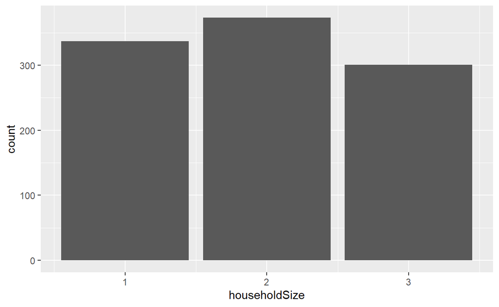

It’s nice to know that we have a lower limit of 1 and an upper limit of 3 members, in terms of household size.

**haveKids**

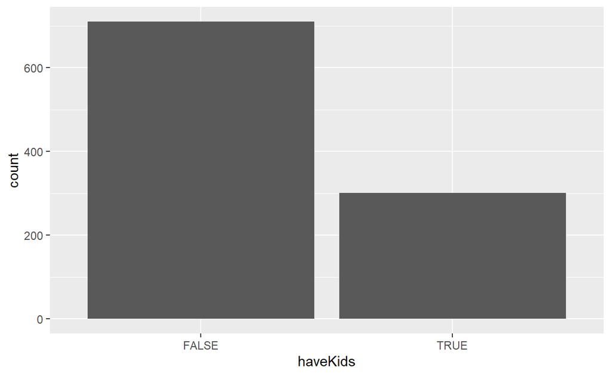

Less people have kids.

**age**

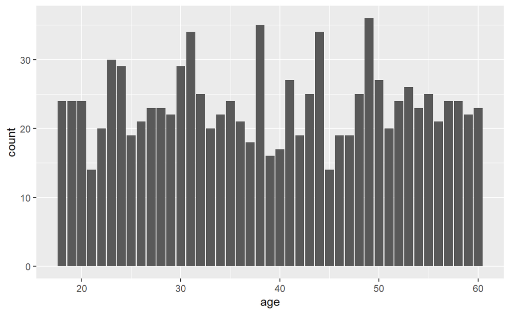

There doesn’t seem to be a clear pattern here. Perhaps I could rearrange the data here in ascending order to have a better gauge. Or I could peg it against another variable to support a hypothesis.

**educationLevel**

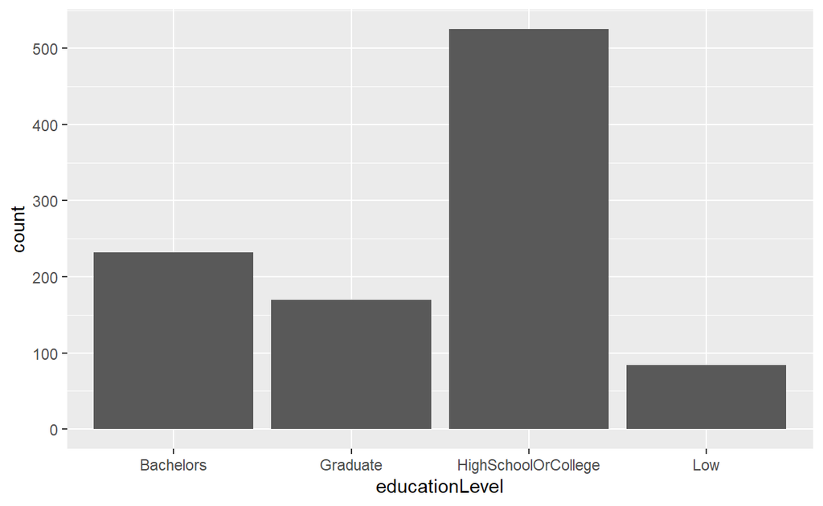

It’s interesting to see that the bulk of of people are went to *HighSchoolOrCollege* which is quite confusing since College and Bachelors mean that same thing.

**interestGroup**

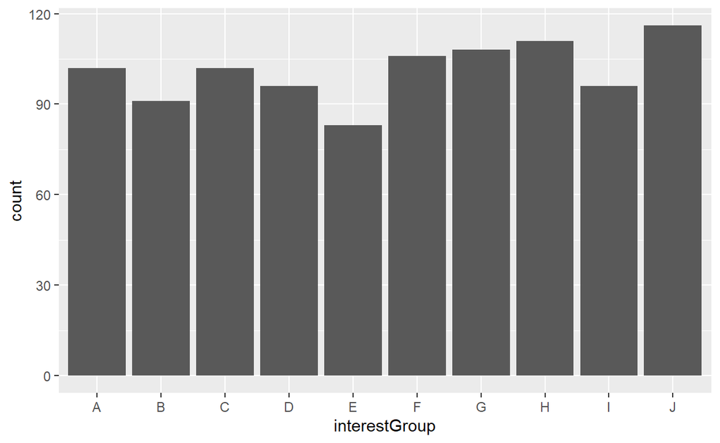

Again not the most helpful. I’ll definitely have to peg it against another variable to give this variable more meaning.

**joviality**

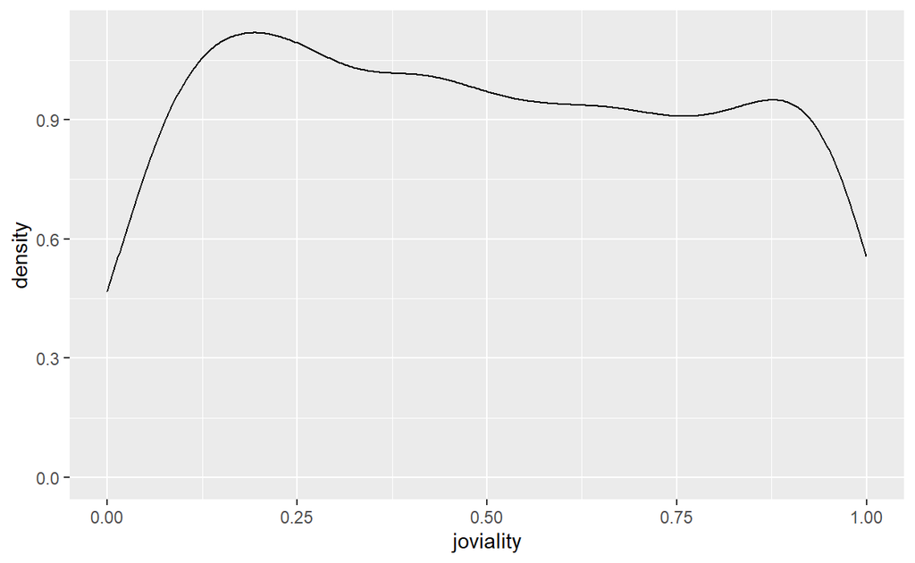

It’s nice to know that most people are happier than 0.45.

# Further Analysis

I think the most interesting thing to understand here is what determines whether or not one has kids. However, given my personal time constraint, I will leave this to further exploration in future exercises. More specifically, I will like to find the correlation between *haveKids* and *educationLevel*, *interestGroup* and *joviality.*